# Lecture 1

Syllabus, Course Outline, Python Basics

Byeong-Hak Choe

bchoe@geneseo.edu

SUNY Geneseo

February 6, 2024

# Instructor

## Instructor

### Current Appointment & Education

- Name: Byeong-Hak Choe.
- Assistant Professor of Data Analytics and Economics, School of Business at SUNY Geneseo.
- Ph.D. in Economics from University of Wyoming.
- M.S. in Economics from Arizona State University.
- M.A. in Economics from SUNY Stony Brook.
- B.A. in Economics & B.S. in Applied Mathematics from Hanyang University at Ansan, South Korea.
  - Minor in Business Administration.
  - Concentration in Finance.

## Instructor

### Economics, Data Science, and Climate Change

- I consider myself an applied economist specializing in environmental economics, with a specific emphasis on climate change.
- My methodological approach involves leveraging causal inference, econometrics, machine learning methods, and various data science tools for conducting empirical analyses.
- Choe, B.H., 2021. “Social Media Campaigns, Lobbying and Legislation: Evidence from #climatechange/#globalwarming and Energy Lobbies.”
- Choe, B.H. and Ore-Monago, T., 2024. “Governance and Climate Finance in the Developing World”

# Syllabus

## Syllabus

### Email, Class & Office Hours

- Email: bchoe@geneseo.edu
- Class Homepage:
  1. [Brightspace](https://mylearning.suny.edu/d2l/home/1231033)
  2. [GitHub Website](http://bcdanl.github.io/module-1/)
- Office: South Hall 301
- Office Hours:
  - To be determined; By appointment via email.

## Syllabus

### Course Description

- This course aims to provide overview of how one can process, clean, and crunch datasets with practical case studies.
- Key topics include:
  1. loading, slicing, filtering, transforming, reshaping, and merging data
  2. summarizing and visualizing data,
  3. exploratory data analysis.
- We will cover these topics to solve real-world data analysis problems with thorough, detailed examples.

## Syllabus

### Reference Materials

- [Python for Data Analysis (3rd Edition)](https://wesmckinney.com/book) by [Wes McKinney](https://wesmckinney.com/)
- [Python Programming for Data Science](https://www.tomasbeuzen.com/python-programming-for-data-science) by Tomas Beuzen
- [Coding for Economists](https://aeturrell.github.io/coding-for-economists) by Arthur Turrell
- [Python for Econometrics in Economics](https://pyecon.org/lecture/%7D%7Bhttps://pyecon.org/lecture/) by Fabian H. C. Raters
- [QuantEcon DataScience - Python Fundamentals](https://datascience.quantecon.org/python_fundamentals/index.html) by Chase Coleman, Spencer Lyon, and Jesse Perla
- [QuantEcon DataScience - pandas](https://datascience.quantecon.org/pandas/index.html) by Chase Coleman, Spencer Lyon, and Jesse Perla

## Syllabus

### Course Requirements

- Laptop or personal computer
  - Operating System: **Mac** or **Windows**.
  - Specification: 2+ core CPU, 4+ GB RAM, and 500+ GB disk storage.
- **Homework**: There will be six homework assignments.
- **Exam**: There will be one take-home exam.
- **Discussions**: You are encouraged to participate in GitHub-based online discussions.
  - Checkout the netiquette policy in the syllabus.

## Syllabus

### Course Schedule and Contents

There will be tentatively 7 class sessions.

| Week | Contents | HW.Exam |
| --- | --- | --- |
| 1 | Syllabus, Python Basics | HW 1 |
| 2 | Pandas Basics; Slicing Series and DataFrame objects | HW 2 |
| 3 | Filtering, Sorting, Ranking, and Visualizing Data | HW 3 |
| 4 | Group Operations | HW 4 |
| 5 | Reshaping DataFrames | HW 5 |
| 6 | Joining DataFrames | HW 6 |
| 7 | Missing Data; Time-series Data; Course wrap-up | Exam |

## Syllabus

### Assessments

$$\begin{align}
(\text{Total Percentage Grade}) =\quad\, &0.60\times(\text{Total Homework Score})\notag\\
\,+\, &0.30\times(\text{Take-Home Exam Score})\notag\\
\,+\, &0.10\times(\text{Total Discussion Score})\notag
\end{align}$$

- Each of the six homework assignments accounts for 10% of the total percentage grade.
- The exam account for 30% of the total percentage grade.
- Participation in discussions accounts for 10% of the total percentage grade.

# Prologue

## Why Data Analytics?

- Fill in the gaps left by traditional business and economics classes.
  - Practical skills that will benefit your future career.
  - Neglected skills like how to actually find datasets in the wild and clean them.
- Data analytics skills are largely distinct from (and complementary to) the core quantitative works familiar to business undergrads.
  - Data visualization, cleaning and wrangling; databases; machine learning; etc.
- In short, we will cover things that I wish someone had taught me when I was undergraduate to prepare my post-graduate career.

## You, at the end of this course

[figure not shown]

## Why Data Analytics?

- **Data analysts** use analytical tools and techniques to extract meaningful insights from data.
  - Skills in data analytics are also useful for **business analysts** or **market analysts**.
- [Breau of Labor Statistics](https://www.bls.gov/ooh/math/data-scientists.htm) forecasts that the projected growth rate of the employment in the industry related to data analytics from 2021 to 2031 is **36%**.
  - The average growth rate for all occupations is **5%**.

## Why Python, R, and Databases?

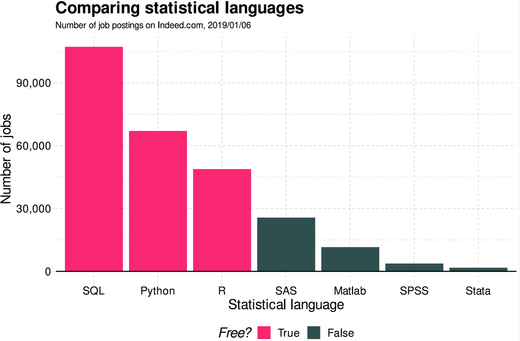

## Why Python, R, and Databases?

### Most Popular Languagues

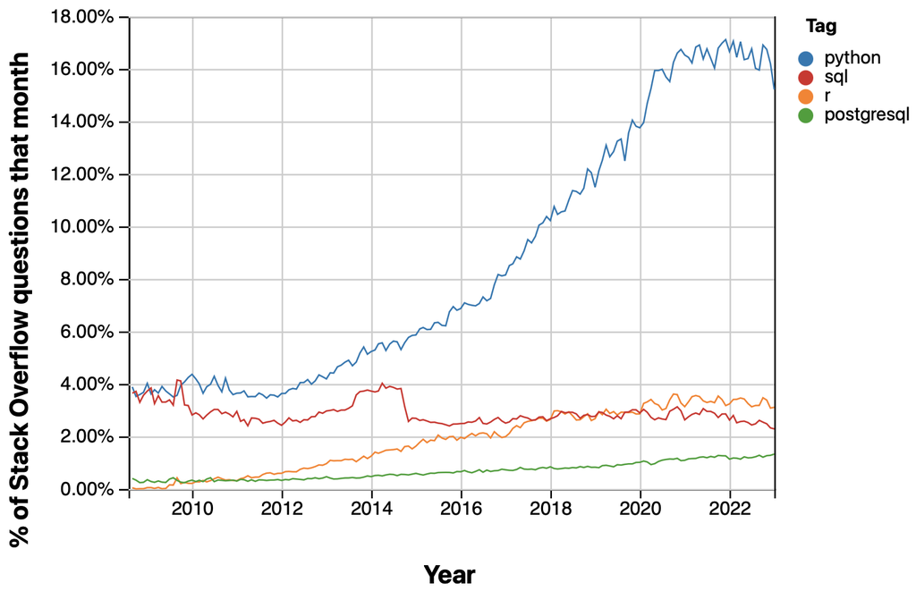

### Data Science and Big Data

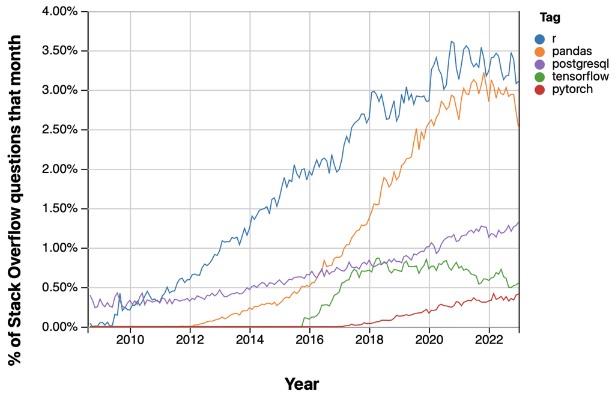

- [Stack Overflow](https://stackoverflow.com) is the most popular Q & A website specifically for programmers and software developers in the world.
- See how programming languages have trended over time based on use of their tags in Stack Overflow from 2008 to 2022.

## The State of the Art

### Generative AI and ChatGPT

### Data Science and Big Data Trend

From 2008 to **2023**

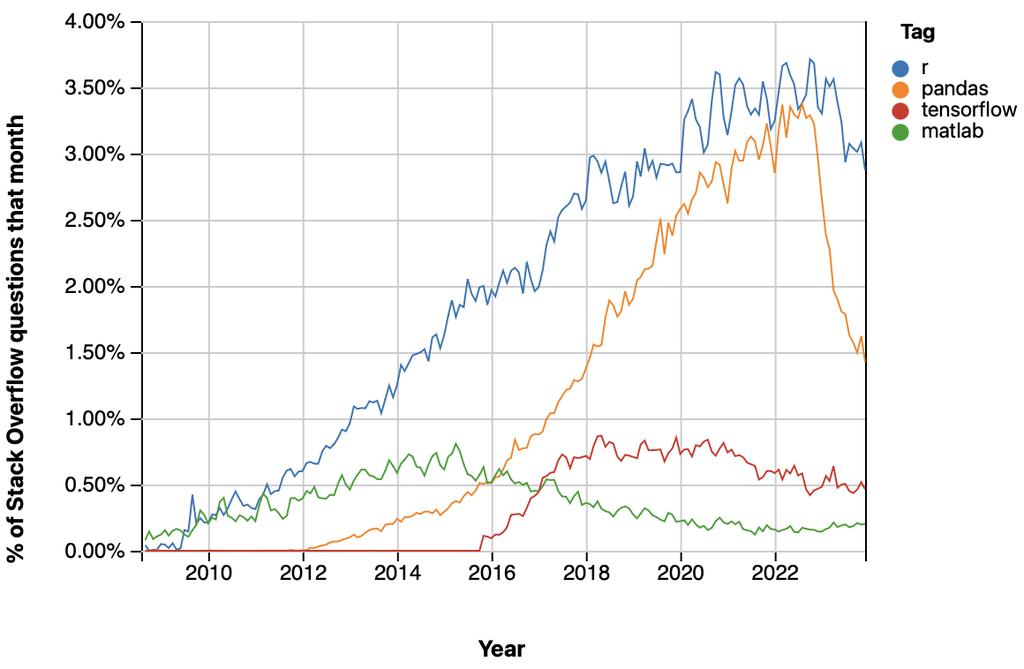

### Programmers in 2024

[figure not shown]

## The State of the Art

### Generative AI and ChatGPT

- Users around the world have explored how to best utilize generative pre-trained transformer (GPT) for writing essays and programming codes.
- Is AI a threat to data analytics?
  - Fundamental understanding of the subject matter is still crucial for effectively utilizing AI’s capabilities.
- If we use Generative AI such as ChatGPT, we should try to understand what Generative AI gives us.
  - Copying and pasting it without understanding harms our learning opportunity.

# DANL Tools

## What is Python?

- Python is a, simple, easy-to-read, and fast programming language, making it an excellent choice for beginners and experienced developers alike.
  - Versatility: Python’s extensive library and the vast ecosystem of third-party modules make it suitable for a wide range of applications, from *web development* and *data analysis* to *machine learning*, *AI* and *scientific computing*.

## What is GitHub?

- [GitHub](https://github.com/) is a web-based hosting platform for Git repositories to store, manage, and share code.
- Github is useful for many reasons, but the main reason is how user friendly it makes uploading and sharing code.
- We will use a GitHub repository to store Python Notebooks.
- Course contents will be posted not only in Brightspace but also in our GitHub repositories (“repos”) and websites.

## What is Google Colab?

- [Google Colab](https://colab.research.google.com/) is analogous to Google Drive, but specifically for writing and executing Python code in your web browser.
- A key benefit of Colab is that it is entirely free to use and has many of the standard Python modules pre installed.
  - It allows for CPU or GPU usage, even for free users, and stores the files in Google’s servers so you can access your files from anywhere you can connect to the Internet.
- Using Colab also means you can entirely avoid the process of installing Python and any dependencies onto your computer.
- Colab notebooks don’t just contain Python code. They can contain text, images, and HTML via **Markdown**!

## How do we use Google Colab with GitHub?

- [How do we use Google Colab with GitHub?](https://bcdanl.github.io/module-1/why-colab-github.html)

# Python Basics

## Python Basics

### Variables Are Names, Not Places

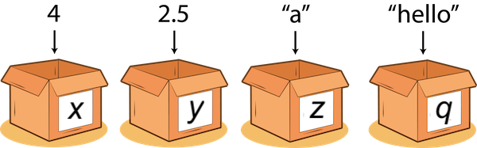

- A **value** is datum (literal) such as a number or text.
- There are different types of values:
  - 352.3 is known as a float or double;
  - 22 is an integer;
  - “Hello World!” is a string.

## Python Basics

### Values, Variables, and Types

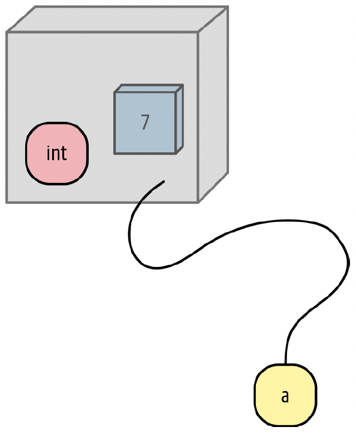

```python
a = 10
print(a)
```

- A **variable** is a name that refers to a value.
  - We can think of a **variable** as a box that has a value, or multiple values, packed inside it.
- A **variable** is just a name!

## Python Basics

### Values, Variables, and Types

- Sometimes you will hear variables referred to as **objects**.
- Everything that is not a *literal value*, such as `10`, is an **object**.

## Python Basics

### Assignment ( `=` )

```python
# Here we assign the integer value 5 to the variable x.
x = 5

# Now we can use the variable x in the next line.
y = x + 12
y
```

- In Python, we use `=` to assign a value to a variable.
- In math, `=` means *equality* of both sides.
- In programs, `=` means **assignment**: *assign the value on the right side to the variable on the left side*.

## Python Basics

### Code and comment style

- The two main principles for coding and managing data are:
  - Make things easier for your future self.
  - Don’t trust your future self.
- The `#` mark is Google Colab’s comment character.
  - The `#` character has many names: `hash`, `sharp`, `pound`, or `octothorpe`.
  - `#` indicates that the rest of the line is to be ignored.
  - Write comments before the line that you want the comment to apply to.
- Consider adding more comments on code cells and their results using text cells.

## Python Basics

### Assignment

- In programming code, everything on the right side needs to have a value.
  - The right side can be a literal value, or a variable that has already been assigned a value, or a combination.
- When Python reads `y = x + 12`, it does the following:
  1. Sees the `=` in the middle.
  2. Knows that this is an assignment.
  3. Calculates the right side (gets the value of the object referred to by `x` and adds it to `12`).
  4. Assigns the result to the left-side variable, `y`.

## Python Basics

### Variables Are Names, Not Places

```python
list_example = [10, 1.23, "like this", True, None]
print(list_example)
type(list_example)
```

- The most basic built-in data types that we’ll need to know about are:
  - **integers** `10`
  - **floats** `1.23`
  - **strings** `"like this"`
  - **booleans** `True`
  - **nothing** `None`
- Python also has a built-in type of data container called a **list** (e.g., `[10, 15, 20]`) that can *contain* anything, even different **types**

## Python Basics

### Types

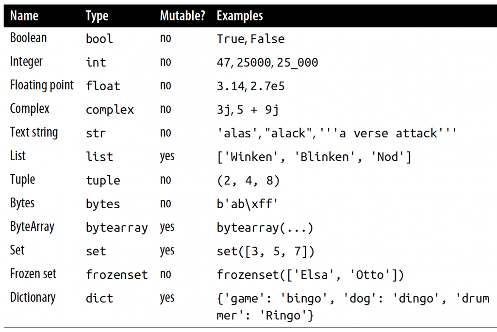

- The second column (Type) contains the Python name of that type.
- The third column (Mutable?) indicates whether the value can be changed after creation.

## Python Basics

### Brackets

- There are several kinds of brackets in Python, including `[]`, `{}`, and `()`.
- `[]`
- `{}`
- `()`

```python
vector = ['a', 'b']
vector[0]
```

- `[]` is used to denote a **list** or to signify accessing a *position* using an index.

```python
{'a', 'b'}  # set
{'first_letter': 'a', 'second_letter': 'b'}  # dictionary
```

- `{}` is used to denote a **set** or a **dictionary** (with key-value pairs).

```python
num_tup = (1, 2, 3)
sum(num_tup)
```

- `()` is used to denote
  - a **tuple**, or
  - the *arguments* to a *function*, e.g., function(x) where x is the input passed to the function.

## Python Basics

### Operators

```python
string_one = "This is an example "
string_two = "of string concatenation"
string_full = string_one + string_two
print(string_full)
```

- All of the basic operators we see in mathematics are available to use:
- `+` for addition
- `-` for subtraction
- `*` for multiplication
- `**` for powers
- `/` for division
- `//` for integer division
- These work as you’d expect on numbers.
- These operators are sometimes defined for other built-in data types too.
  - We can ‘sum’ strings (which really *concatenates* them).

## Python Basics

### Operators

```python
list_one = ["apples", "oranges"]
list_two = ["pears", "satsumas"]
list_full = list_one + list_two
print(list_full)
```

- It works for lists too:

```python
string = "apples, "
print(string * 3)
```

- We can multiply strings!

## Python Basics

### Operators

**Q**. [Classwork 1.1](https://bcdanl.github.io/module-1/danl-cw/danl-m1-cw-1.html#question-1)

Using Python operations only, calculate below:
$$\frac{2^5}{7 \cdot (4 - 2^3)}$$

## Python Basics

### Booleans and Conditions

```python
10 == 20
10 == '10'
```

- Boolean data have either `True` or `False` value.

## Python Basics

### Booleans and Conditions

| Operator | Description |
| --- | --- |
| x and y | Are x and y both True? |
| x or y | Is at least one of x and y True? |
| not x | Is x False? |

- Existing booleans can be combined, which create a boolean when executed.

## Python Basics

### Booleans and Conditions

Conditions are expressions that evaluate as booleans.

[output not shown]

## Python Basics

### Booleans and Conditions

```python
boolean_condition1 = 10 == 20
print(boolean_condition1)

boolean_condition2 = 10 == '10'
print(boolean_condition2)
```

- The `==` is an operator that compares the objects on either side and returns `True` if they have the same values
- **Q**. What does `not (not True)` evaluate to?
- **Q**. [Classwork 1.2](https://bcdanl.github.io/module-1/danl-cw/danl-m1-cw-1.html#question-2)

## Python Basics

### Booleans and Conditions

```python
name = "Geneseo"
score = 99

if name == "Geneseo" and score > 90:
    print("Geneseo, you achieved a high score.")

if name == "Geneseo" or score > 90:
    print("You could be called Geneseo or have a high score")

if name != "Geneseo" and score > 90:
    print("You are not called Geneseo and you have a high score")
```

- The real power of conditions comes when we start to use them in more complex examples, such as `if` statements.

## Python Basics

### Booleans and Conditions

```python
name_list = ["Lovelace", "Smith", "Hopper", "Babbage"]

print("Lovelace" in name_list)

print("Bob" in name_list)
```

- One of the most useful conditional keywords is `in`.
  - This one must pop up ten times a day in most coders’ lives because it can pick out a variable or make sure something is where it’s supposed to be.
- **Q**. Check if “a” is in the string “Sun Devil Arena” using `in`. Is “a” in “Anyone”?

## Python Basics

### Booleans and Conditions

```python
score = 98

if score == 100:
    print("Top marks!")
elif score > 90 and score < 100:
    print("High score!")
elif score > 10 and score <= 90:
    pass
else:
    print("Better luck next time.")
```

- One conditional construct we’re bound to use at some point, is the `if-else` chain:

## Python Basics

### Casting Variables

```python
orig_number = 4.39898498
type(orig_number)
```

```python
mod_number = int(orig_number)
mod_number
type(mod_number)
```

- Sometimes we need to explicitly cast a value from one type to another.
  - We can do this using built-in functions like `str()`, `int()`, and `float()`.
  - If we try these, Python will do its best to interpret the input and convert it to the output type we’d like and, if they can’t, the code will throw a great big error.

## Python Basics

### Tuples and (im)mutability

- A tuple is an object that is defined by parentheses and entries that are separated by commas, for example `(15, 20, 32)`. (They are of type tuple.)
- Tuples are immutable, while lists are mutable.
- Immutable objects, such as tuples and strings, can’t have their elements changed, appended, extended, or removed.
  - Mutable objects, such as lists, can do all of these things.
- In everyday programming, we use **lists** and **dictionaries** more than *tuples*.

## Python Basics

### Indentation

- We have seen that certain parts of the code examples are indented.
- Code that is part of a function, a conditional clause, or loop is indented.
- Indention is actually what tells the Python interpreter that some code is to be executed as part of, say, a loop and not to executed after the loop is finished.

## Python Basics

### Indentation

```python
x = 10

if x > 2:
    print("x is greater than 2")
```

- Here’s a basic example of indentation as part of an `if` statement.
- The standard practice for indentation is that each sub-statement should be indented by 4 spaces.

## Python Basics

### `for` Loops

```python
name_list = ["Ben", "Chris", "Kate", "Mary"]

for name in name_list:
    print(name)
```

- A loop is a way of executing a similar piece of code over and over in a similar way.
  - The most useful loop is **for loops**.
- As long as our object is an iterable, then it can be used in this way in a *for loop*.
- Lists, tuples, strings, and dictionaries are iterable.

## Python Basics

### Dictionaries

```python
cities_to_temps = {"Paris": 28, "London": 22, "Seville": 36, "Wellesley": 29}

cities_to_temps.keys()
cities_to_temps.values()
cities_to_temps.items()
```

- Another built-in Python type that is enormously useful is the dictionary.
  - This provides a mapping one set of variables to another (either one-to-one or many-to-one).
  - If you need to create associations between objects, use a dictionary.
- We can obtain keys, values, or key-value paris from dictionaries.